# Tugas 1 MPDW

Arfiah Kania Sektiaruni

2023-09-04

## Library

```r
library("forecast")
```

```r
library("graphics")
library("TTR")
library("TSA")
```

## Impor Data

```r
library(rio)
datampdw <- import("https://raw.githubusercontent.com/afhkaniase/praktikum-mpdw/main/Data/Data%20Temperatur%20Portugal%202023.csv")
datampdw
```

```
##     Periode Temperature
## 1         1        15.9
## 2         2        11.1
## 3         3        10.2
## 4         4         9.9
## 5         5         9.9
## 6         6        11.0
## 7         7        14.8
## 8         8        16.2
## 9         9        15.4
## 10       10        14.4
## 11       11        13.9
## 12       12        11.5
## 13       13        11.6
## 14       14        10.5
```

[output cut: 198 more lines]

## Eksplorasi Data

```r
View(datampdw)
str(datampdw)
```

```
## 'data.frame':    212 obs. of  2 variables:
##  $ Periode    : int  1 2 3 4 5 6 7 8 9 10 ...
##  $ Temperature: num  15.9 11.1 10.2 9.9 9.9 11 14.8 16.2 15.4 14.4 ...
```

```r
dim(datampdw)
```

```
## [1] 212   2
```

## Mengubah data agar terbaca sebagai data deret waktu dengan fungsi `ts()` .

```r
datampdw.ts <- ts(datampdw$Temperature)
datampdw.ts
```

```
## Time Series:
## Start = 1
## End = 212
## Frequency = 1
##   [1] 15.9 11.1 10.2  9.9  9.9 11.0 14.8 16.2 15.4 14.4 13.9 11.5 11.6 10.5 11.6
##  [16] 12.9 12.8  9.4  9.9 14.0 13.7 10.2  8.2  8.3  7.6  8.8  9.3  8.3  7.5  7.5
##  [31]  8.5  8.3  8.3 10.0 11.6 11.7 11.0  9.7  9.5 12.1 10.4  9.6 11.4 12.3 12.3
##  [46] 14.4 13.7 13.9 14.4 13.9 13.8 13.5 12.5  9.8  7.9  8.8 10.6  9.9  8.5  8.1
##  [61]  8.2  9.5 10.5 11.7 13.3 14.2 15.8 16.5 15.4 16.9 15.2 15.2 14.4 14.3 13.2
##  [76] 14.7 13.7 14.5 14.7 14.3 13.9 14.1 16.0 14.2 15.6 15.7 17.4 17.0 16.8 17.0
##  [91] 15.8 16.3 15.1 17.7 19.0 19.0 17.5 17.1 18.2 16.1 16.7 15.3 13.2 14.7 18.1
## [106] 20.2 22.9 21.4 19.2 16.2 14.4 15.8 16.7 18.7 18.6 20.2 23.7 21.6 18.8 19.0
## [121] 21.0 21.7 20.4 18.7 18.2 18.9 19.2 19.4 19.5 17.4 17.6 16.7 17.7 18.1 17.4
## [136] 19.8 21.6 20.0 19.5 19.3 18.2 18.1 19.2 20.2 21.8 17.7 18.8 18.5 18.2 19.0
## [151] 18.9 19.4 20.0 20.1 20.6 21.6 22.0 21.4 20.0 20.0 20.9 20.1 20.6 20.0 21.0
## [166] 24.0 24.4 22.1 21.3 20.5 20.4 19.9 21.7 26.0 27.4 25.1 24.7 23.7 23.6 21.5
## [181] 21.9 23.7 24.6 22.2 21.5 21.4 21.5 21.1 21.9 21.5 23.3 22.5 22.8 23.9 22.7
## [196] 21.7 20.3 22.0 22.2 21.8 21.3 21.2 21.6 20.9 21.4 20.6 22.4 20.5 22.2 23.3
## [211] 22.6 21.9
```

## Menampilkan ringkasan data

```r
summary(datampdw.ts)
```

```
##    Min. 1st Qu.  Median    Mean 3rd Qu.    Max.
##    7.50   13.65   17.45   16.82   20.90   27.40
```

## Membuat plot data deret waktu

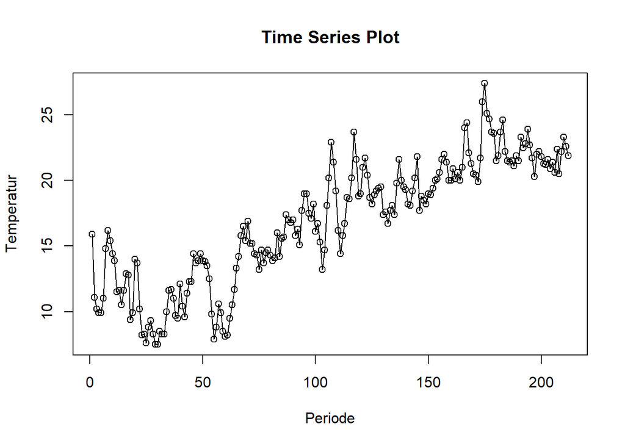

```r
ts.plot(datampdw.ts, xlab="Periode", ylab="Temperatur",
        main = "Time Series Plot")
points(datampdw.ts)
```

```r
#Pola data trend
```

### Membagi data per bulan

```r
Januari <- datampdw[1:31,]
Februari <- datampdw[32:59,]
Maret <- datampdw[60:90,]
April <- datampdw[91:120,]
Mei <- datampdw[121:151,]
Juni <- datampdw[152:181,]
Juli <- datampdw[182:212,]
```

### Mengubah data per bulan agar terbaca sebagai data deret waktu

```r
Januari.ts <- ts((datampdw[1:31,])$Temperature)
Februari.ts <- ts((datampdw[32:59,])$Temperature)
Maret.ts  <- ts((datampdw[60:90,])$Temperature)
April.ts  <-ts(( datampdw[91:120,])$Temperature)
Mei.ts  <- ts((datampdw[121:151,])$Temperature)
Juni.ts  <- ts((datampdw[152:181,])$Temperature)
Juli.ts  <- ts((datampdw[182:212,])$Temperature)
```

### Eksplorasi data per bulan

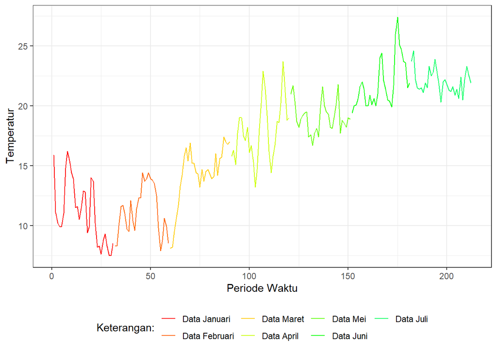

```r
library(ggplot2)
ggplot() +
  geom_line(data = Januari, aes(x = Periode, y = Temperature, col = "Data Januari")) +
  geom_line(data = Februari, aes(x = Periode, y = Temperature, col = "Data Februari")) +
  geom_line(data = Maret, aes(x = Periode, y = Temperature, col = "Data Maret")) +
  geom_line(data = April, aes(x = Periode, y = Temperature, col = "Data April")) +
  geom_line(data = Mei, aes(x = Periode, y = Temperature, col = "Data Mei")) +
  geom_line(data = Juni, aes(x = Periode, y = Temperature, col = "Data Juni")) +
  geom_line(data = Juli, aes(x = Periode, y = Temperature, col = "Data Juli")) +
  labs(x = "Periode Waktu", y = "Temperatur", color = "Legend") +
  scale_colour_manual(name="Keterangan:", breaks = c("Data Januari", "Data Februari","Data Maret","Data April", "Data Mei", "Data Juni", "Data Juli", "Data Agustus", "Data September","Data Oktober", "Data November", "Data Desember"),
                      values = rainbow(15)) +
  theme_bw() + theme(legend.position = "bottom",
                     plot.caption = element_text(hjust=0.5, size=12))
```

Plot data di atas menunjukkan bahwa data per bulan mengalami kenaikan sehingga plot tersebut memiliki pola data trend. Untuk melakukan melakukan metode pemulusan pada data trend bisa menggunakan Single Moving Average & Double Moving Average.

## Single Moving Average & Double Moving Average

### Pembagian Data

Pembagian data latih dan data uji dilakukan dengan perbandingan 80% data latih dan 20% data uji.

```r
#membagi data latih dan data uji
training_ma <- datampdw[1:169,]
testing_ma <- datampdw[170:212,]

#Membuat plot deret waktu data dari data training dan testing
train_ma.ts <- ts(training_ma$Temperature)
test_ma.ts <- ts(testing_ma$Temperature)
```

### Eksplorasi data training dan testing

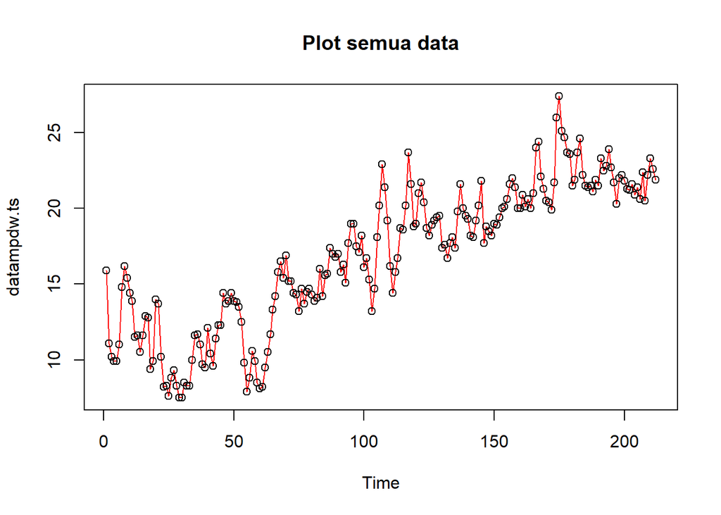

```r
#eksplorasi keseluruhan data
plot(datampdw.ts, col="red",main="Plot semua data")
points(datampdw.ts)
```

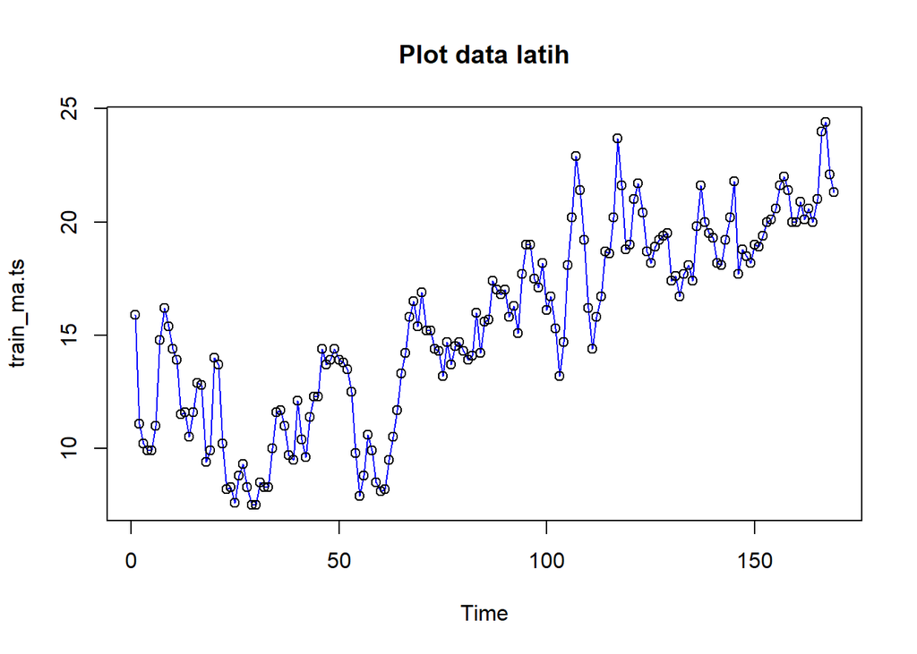

```r
#eksplorasi data latih (data training)
plot(train_ma.ts, col="blue",main="Plot data latih")
points(train_ma.ts)
```

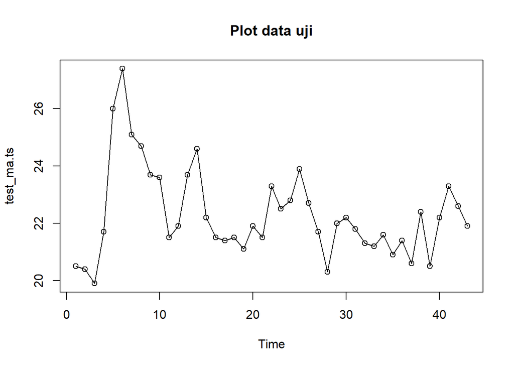

```r
#eksplorasi data uji (data test)
plot(test_ma.ts, col="black",main="Plot data uji")
points(test_ma.ts)
```

[figure not shown]

```r
#Eksplorasi dengan GGPLOT
library(ggplot2)
ggplot() +
  geom_line(data = training_ma, aes(x = Periode, y = Temperature, col = "Data Training")) +
  geom_line(data = training_ma, aes(x = Periode, y = Temperature, col = "Data Testing")) +
  labs(x = "Periode Waktu", y = "Temperatur", color = "Legend") +
  scale_colour_manual(name="Keterangan:", breaks = c("Data Training", "Data Testing"),
                      values = c("blue", "red")) +
  theme_bw() + theme(legend.position = "bottom",
                     plot.caption = element_text(hjust=0.5, size=10))
```

### Single Moving Average

```r
data.sma<-SMA(train_ma.ts)
data.sma
```

```
## Time Series:
## Start = 1
## End = 169
## Frequency = 1
##   [1]    NA    NA    NA    NA    NA    NA    NA    NA    NA 12.88 12.68 12.72
##  [13] 12.86 12.92 13.09 13.28 13.08 12.40 11.85 11.81 11.79 11.66 11.32 11.10
##  [25] 10.70 10.29  9.94  9.83  9.59  8.94  8.42  8.23  8.24  8.41  8.81  9.10
##  [37]  9.27  9.41  9.61 10.07 10.26 10.39 10.70 10.93 11.00 11.27 11.54 11.96
##  [49] 12.45 12.63 12.97 13.36 13.47 13.22 12.78 12.22 11.91 11.51 10.92 10.34
##  [61]  9.78  9.38  9.18  9.37  9.91 10.45 10.97 11.63 12.32 13.20 13.90 14.47
##  [73] 14.86 15.12 15.11 15.16 14.95 14.75 14.68 14.42 14.29 14.18 14.34 14.33
##  [85] 14.57 14.67 15.04 15.29 15.50 15.77 15.96 16.18 16.09 16.44 16.78 17.11
##  [97] 17.12 17.13 17.27 17.18 17.27 17.17 16.98 16.68 16.59 16.71 17.25 17.68
## [109] 17.78 17.79 17.56 17.61 17.96 18.36 18.41 18.41 18.49 18.51 18.47 18.75
## [121] 19.41 20.00 20.37 20.37 20.33 20.20 19.75 19.53 19.60 19.44 19.10 18.60
## [133] 18.33 18.27 18.19 18.28 18.52 18.58 18.58 18.77 18.83 18.97 19.12 19.33
## [145] 19.77 19.56 19.28 19.13 19.00 18.97 19.04 19.17 19.25 19.24 19.12 19.51
## [157] 19.83 20.12 20.30 20.40 20.60 20.67 20.73 20.72 20.76 21.00 21.24 21.31
## [169] 21.44
```

Data pemulusan pada periode ke-t selanjutnya digunakan sebagai nilai peramalan pada periode ke t+1 sehingga hasil peramalan 1 periode kedepan adalah sebagai berikut.

```r
data.ramalan<-c(NA,data.sma)
data.ramalan #forecast 1 periode ke depan
```

```
##   [1]    NA    NA    NA    NA    NA    NA    NA    NA    NA    NA 12.88 12.68
##  [13] 12.72 12.86 12.92 13.09 13.28 13.08 12.40 11.85 11.81 11.79 11.66 11.32
##  [25] 11.10 10.70 10.29  9.94  9.83  9.59  8.94  8.42  8.23  8.24  8.41  8.81
##  [37]  9.10  9.27  9.41  9.61 10.07 10.26 10.39 10.70 10.93 11.00 11.27 11.54
##  [49] 11.96 12.45 12.63 12.97 13.36 13.47 13.22 12.78 12.22 11.91 11.51 10.92
##  [61] 10.34  9.78  9.38  9.18  9.37  9.91 10.45 10.97 11.63 12.32 13.20 13.90
##  [73] 14.47 14.86 15.12 15.11 15.16 14.95 14.75 14.68 14.42 14.29 14.18 14.34
##  [85] 14.33 14.57 14.67 15.04 15.29 15.50 15.77 15.96 16.18 16.09 16.44 16.78
##  [97] 17.11 17.12 17.13 17.27 17.18 17.27 17.17 16.98 16.68 16.59 16.71 17.25
## [109] 17.68 17.78 17.79 17.56 17.61 17.96 18.36 18.41 18.41 18.49 18.51 18.47
## [121] 18.75 19.41 20.00 20.37 20.37 20.33 20.20 19.75 19.53 19.60 19.44 19.10
## [133] 18.60 18.33 18.27 18.19 18.28 18.52 18.58 18.58 18.77 18.83 18.97 19.12
## [145] 19.33 19.77 19.56 19.28 19.13 19.00 18.97 19.04 19.17 19.25 19.24 19.12
## [157] 19.51 19.83 20.12 20.30 20.40 20.60 20.67 20.73 20.72 20.76 21.00 21.24
## [169] 21.31 21.44
```

```r
data.gabungan<-cbind(aktual=c(train_ma.ts,rep(NA,43)),pemulusan=c(data.sma,rep(NA,43)),ramalan=c(data.ramalan,rep(data.ramalan[length(data.ramalan)],42)))

head(data.gabungan) #forecast 42 periode ke depan
```

```
##      aktual pemulusan ramalan
## [1,]   15.9        NA      NA
## [2,]   11.1        NA      NA
## [3,]   10.2        NA      NA
## [4,]    9.9        NA      NA
## [5,]    9.9        NA      NA
## [6,]   11.0        NA      NA
```

Plot deret waktu data peramalan

[figure not shown]

```r
ts.plot(datampdw.ts, xlab="Time Period ", ylab="Temperature", main= "SMA N = 9 Data Temperature di Portugal Tahun 2023")
points(datampdw.ts)
lines(data.gabungan[,2],col="green",lwd=2)
lines(data.gabungan[,3],col="red",lwd=2)
legend("topleft",c("data aktual","data pemulusan","data peramalan"), lty=8, col=c("black","green","red"), cex=0.5)
```

Selanjutnya perhitungan akurasi dilakukan dengan ukuran akurasi **Sum Squares Error** (SSE), **Mean Square Error** (MSE) dan **Mean Absolute Percentage Error** (MAPE). Perhitungan akurasi dilakukan baik pada data latih maupun pada data uji.

```r
#Menghitung nilai keakuratan data latih
error_train.sma = train_ma.ts-data.ramalan[1:length(train_ma.ts)]
SSE_train.sma = sum(error_train.sma[15:length(train_ma.ts)]^2)
MSE_train.sma = mean(error_train.sma[15:length(train_ma.ts)]^2)
MAPE_train.sma = mean(abs((error_train.sma[15:length(train_ma.ts)]/train_ma.ts[15:length(train_ma.ts)])*100))
akurasi_train.sma <- matrix(c(SSE_train.sma, MSE_train.sma, MAPE_train.sma))
row.names(akurasi_train.sma)<- c("SSE", "MSE", "MAPE")
colnames(akurasi_train.sma) <- c("Akurasi m = 6")
akurasi_train.sma
```

```
##      Akurasi m = 6
## SSE     697.142600
## MSE       4.497694
## MAPE     11.983145
```

Dalam hal ini nilai MAPE data latih pada metode pemulusan SMA kurang dari 20%, nilai ini dapat dikategorikan sebagai nilai akurasi yang baik. Selanjutnya dilakukan perhitungan nilai MAPE data uji pada metde pemulusan SMA.

```r
#Menghitung nilai keakuratan data uji
error_test.sma = test_ma.ts-data.gabungan[170:212,3]
SSE_test.sma = sum(error_test.sma^2)
MSE_test.sma = mean(error_test.sma^2)
MAPE_test.sma = mean(abs((error_test.sma/test_ma.ts*100)))

akurasi_test.sma <- matrix(c(SSE_test.sma, MSE_test.sma, MAPE_test.sma))
row.names(akurasi_test.sma)<- c("SSE", "MSE", "MAPE")
colnames(akurasi_test.sma) <- c("Akurasi m = 4")
akurasi_test.sma
```

```
##      Akurasi m = 4
## SSE     135.702800
## MSE       3.155879
## MAPE      5.188949
```

### Double Moving Average (DMA)

```r
dma <- SMA(data.sma, n = 9)
At <- 2*data.sma - dma
Bt <- 2/(9-1)*(data.sma - dma)
data.dma<- At+Bt
data.ramal2<- c(NA, data.dma)

t = 1:43
f = c()

for (i in t) {
  f[i] = At[length(At)] + Bt[length(Bt)]*(i)
}

data.gab2 <- cbind(aktual = c(train_ma.ts,rep(NA,43)), pemulusan1 = c(data.sma,rep(NA,43)),pemulusan2 = c(data.dma, rep(NA,43)),At = c(At, rep(NA,43)), Bt = c(Bt,rep(NA,43)),ramalan = c(data.ramal2, f[-1]))
data.gab2
```

```
##        aktual pemulusan1 pemulusan2        At           Bt   ramalan
##   [1,]   15.9         NA         NA        NA           NA        NA
##   [2,]   11.1         NA         NA        NA           NA        NA
##   [3,]   10.2         NA         NA        NA           NA        NA
##   [4,]    9.9         NA         NA        NA           NA        NA
##   [5,]    9.9         NA         NA        NA           NA        NA
##   [6,]   11.0         NA         NA        NA           NA        NA
##   [7,]   14.8         NA         NA        NA           NA        NA
##   [8,]   16.2         NA         NA        NA           NA        NA
##   [9,]   15.4         NA         NA        NA           NA        NA
##  [10,]   14.4      12.88         NA        NA           NA        NA
##  [11,]   13.9      12.68         NA        NA           NA        NA
##  [12,]   11.5      12.72         NA        NA           NA        NA
##  [13,]   11.6      12.86         NA        NA           NA        NA
##  [14,]   10.5      12.92         NA        NA           NA        NA
```

[output cut: 198 more lines]

Hasil pemulusan menggunakan metode DMA divisualisasikan sebagai berikut

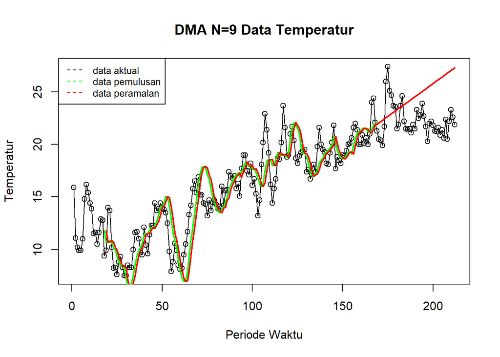

```r
ts.plot(datampdw.ts, xlab="Periode Waktu", ylab="Temperatur", main= "DMA N=9 Data Temperatur")
points(datampdw.ts)
lines(data.gab2[,3],col="green",lwd=2)
lines(data.gab2[,6],col="red",lwd=2)
legend("topleft",c("data aktual","data pemulusan","data peramalan"), lty=8, col=c("black","green","red"), cex=0.8)
```

Kemudian perhitungan akurasi dilakukan baik pada data latih maupun data uji. Perhitungan akurasi dilakukan dengan ukuran akurasi SSE, MSE dan MAPE.

```r
#Menghitung nilai keakuratan data latih
error_train.dma = train_ma.ts-data.ramal2[1:length(train_ma.ts)]
SSE_train.dma = sum(error_train.dma[19:length(train_ma.ts)]^2)
MSE_train.dma = mean(error_train.dma[19:length(train_ma.ts)]^2)
MAPE_train.dma = mean(abs((error_train.dma[19:length(train_ma.ts)]/train_ma.ts[19:length(train_ma.ts)])*100))

akurasi_train.dma <- matrix(c(SSE_train.dma, MSE_train.dma, MAPE_train.dma))
row.names(akurasi_train.dma)<- c("SSE", "MSE", "MAPE")
colnames(akurasi_train.dma) <- c("Akurasi m = 9")
akurasi_train.dma
```

```
##      Akurasi m = 9
## SSE     745.211929
## MSE       4.935178
## MAPE     12.240856
```

Perhitungan akurasi pada data latih menggunakan nilai MAPE menghasilkan nilai MAPE yang kurang dari 20% sehingga dikategorikan baik. Selanjutnya, perhitungan nilai akurasi dilakukan pada data uji.

```r
#Menghitung nilai keakuratan data uji
error_test.dma = test_ma.ts-data.gab2[170:212,6]
SSE_test.dma = sum(error_test.dma^2)
MSE_test.dma = mean(error_test.dma^2)
MAPE_test.dma = mean(abs((error_test.dma/test_ma.ts*100)))

akurasi_test.dma <- matrix(c(SSE_test.dma, MSE_test.dma, MAPE_test.dma))
row.names(akurasi_test.dma)<- c("SSE", "MSE", "MAPE")
colnames(akurasi_test.dma) <- c("Akurasi m = 9")
akurasi_test.dma
```

```
##      Akurasi m = 9
## SSE      510.24065
## MSE       11.86606
## MAPE      13.88270
```

Perhitungan akurasi pada data uji menggunakan nilai MAPE menghasilkan nilai MAPE yang kurang dari 20% sehingga dikategorikan baik.

### Double Exponential Smoothing (DES)

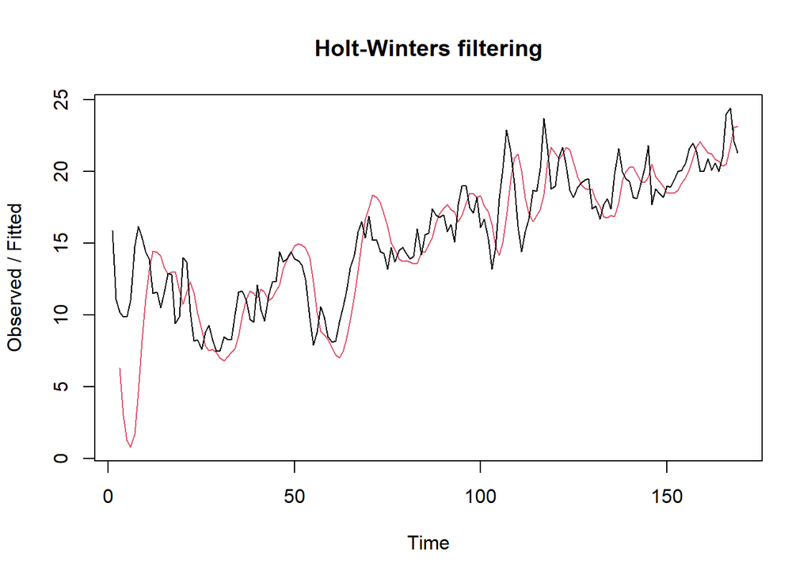

```r
#Lamda=0.2 dan gamma=0.2
des.1<- HoltWinters(train_ma.ts, gamma = FALSE, beta = 0.3, alpha = 0.3)
plot(des.1)
```

```r
#ramalan
ramalandes1<- forecast(des.1, h=43)
ramalandes1
```

```
##     Point Forecast        Lo 80    Hi 80       Lo 95     Hi 95
## 170       22.83001  19.30529998 26.35471  17.4394331  28.22058
## 171       23.05682  19.27354123 26.84009  17.2707958  28.84284
## 172       23.28363  19.13928693 27.42797  16.9454051  29.62185
## 173       23.51044  18.90479286 28.11609  16.4667109  30.55417
## 174       23.73725  18.57743629 28.89706  15.8459958  31.62850
## 175       23.96406  18.16648151 29.76164  15.0974282  32.83069
## 176       24.19087  17.68103411 30.70071  14.2349340  34.14681
## 177       24.41768  17.12912187 31.70624  13.2707906  35.56458
## 178       24.64449  16.51746555 32.77152  12.2152765  37.07371
## 179       24.87130  15.85156800 33.89104  11.0768077  38.66580
## 180       25.09812  15.13590856 35.06032   9.8622345  40.33400
## 181       25.32493  14.37414541 36.27571   8.5771519  42.07270
## 182       25.55174  13.56929089 37.53418   7.2261666  43.87731
## 183       25.77855  12.72385244 38.83325   5.8131136  45.74398
```

[output cut: 29 more lines]

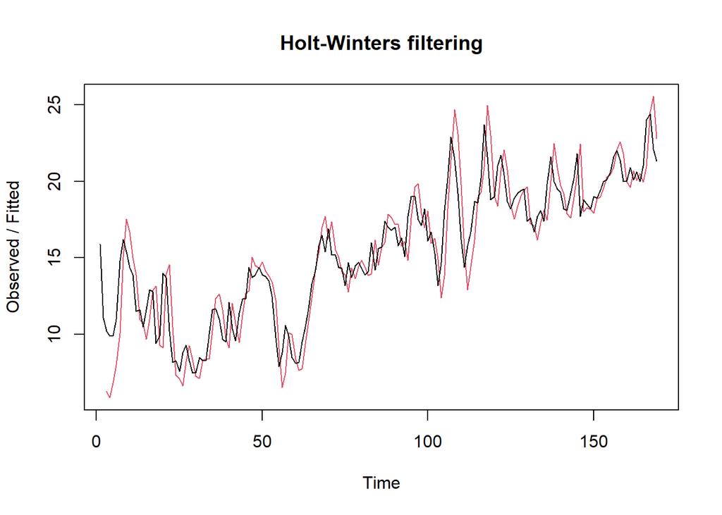

```r
#Lamda=0.8 dan gamma=0.4
des.2<- HoltWinters(train_ma.ts, gamma = FALSE, beta = 0.4, alpha = 0.8)
plot(des.2)
```

```r
#ramalan
ramalandes2<- forecast(des.2, h=43)
ramalandes2
```

```
##     Point Forecast        Lo 80     Hi 80        Lo 95     Hi 95
## 170      21.127607   18.8400746  23.41514   17.6291281  24.62609
## 171      20.656348   17.2216958  24.09100   15.4035008  25.90919
## 172      20.185089   15.4261414  24.94404   12.9069070  27.46327
## 173      19.713829   13.4803140  25.94734   10.1804903  29.24717
## 174      19.242570   11.4006368  27.08450    7.2493680  31.23577
## 175      18.771311    9.1985959  28.34403    4.1311067  33.41152
## 176      18.300052    6.8829044  29.71720    0.8390316  35.76107
## 177      17.828793    4.4605189  31.19707   -2.6162177  38.27380
## 178      17.357533    1.9371893  32.77788   -6.2258478  40.94091
## 179      16.886274   -0.6822131  34.45476   -9.9824084  43.75496
## 180      16.415015   -3.3934836  36.22351  -13.8794694  46.70950
## 181      15.943756   -6.1929402  38.08045  -17.9113992  49.79891
## 182      15.472497   -9.0773201  40.02231  -22.0732080  53.01820
## 183      15.001237  -12.0437042  42.04618  -26.3604314  56.36291
```

[output cut: 29 more lines]

Selanjutnya ingin membandingkan plot data latih dan data uji adalah sebagai berikut.

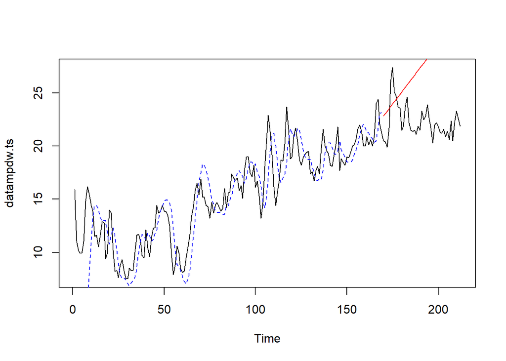

```r
#Visually evaluate the prediction
plot(datampdw.ts)
lines(des.1$fitted[,1], lty=2, col="blue")
lines(ramalandes1$mean, col="red")
```

Untuk mendapatkan nilai parameter optimum dari DES, argumen `alpha` dan `beta` dibuat `NULL` seperti berikut.

```r
#Lamda dan gamma optimum
des.opt<- HoltWinters(train_ma.ts, gamma = FALSE)
des.opt
```

```
## Holt-Winters exponential smoothing with trend and without seasonal component.
##
## Call:
## HoltWinters(x = train_ma.ts, gamma = FALSE)
##
## Smoothing parameters:
##  alpha: 1
##  beta : 0.2354085
##  gamma: FALSE
##
## Coefficients:
##         [,1]
## a 21.3000000
## b -0.1811268
```

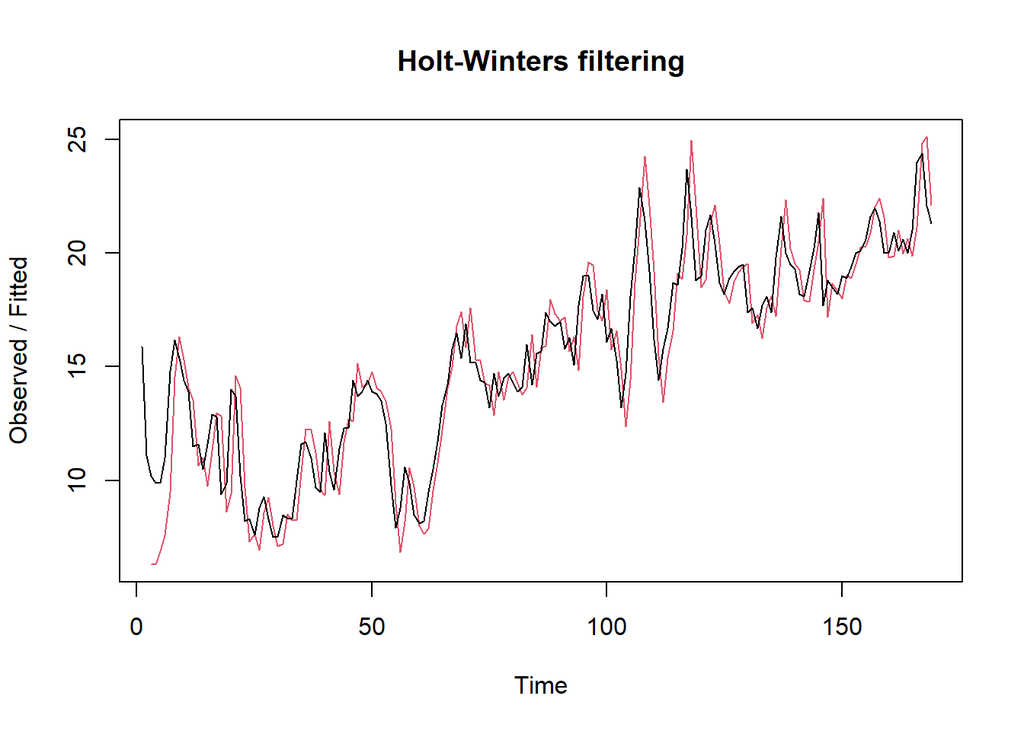

```r
plot(des.opt)
```

```r
#ramalan
ramalandesopt<- forecast(des.opt, h=43)
ramalandesopt
```

```
##     Point Forecast       Lo 80     Hi 80        Lo 95     Hi 95
## 170       21.11887  18.9825030  23.25524   17.8515769  24.38617
## 171       20.93775  17.5421715  24.33332   15.7446627  26.13083
## 172       20.75662  16.1302376  25.38300   13.6811788  27.83206
## 173       20.57549  14.6856389  26.46535   11.5677385  29.58325
## 174       20.39437  13.1904302  27.59830    9.3768969  31.41184
## 175       20.21324  11.6383805  28.78810    7.0991243  33.32735
## 176       20.03211  10.0275749  30.03665    4.7314926  35.33273
## 177       19.85099   8.3579333  31.34404    2.2738788  37.42809
## 178       19.66986   6.6302077  32.70951   -0.2725668  39.61229
## 179       19.48873   4.8455295  34.13194   -2.9061138  41.88358
## 180       19.30761   3.0051901  35.61002   -5.6247873  44.24000
## 181       19.12648   1.1105289  37.14243   -8.4265389  46.67950
## 182       18.94535  -0.8371237  38.72783  -11.3093338  49.20004
## 183       18.76423  -2.8364760  40.36493  -14.2711966  51.79965
```

[output cut: 29 more lines]

Selanjutnya akan dilakukan perhitungan akurasi pada data latih maupun data uji dengan ukuran akurasi SSE, MSE dan MAPE.

#### Akurasi Data Latih

```r
#Akurasi Data Training
ssedes.train1<-des.1$SSE
msedes.train1<-ssedes.train1/length(train_ma.ts)
sisaandes1<-ramalandes1$residuals
head(sisaandes1)
```

```
## Time Series:
## Start = 1
## End = 6
## Frequency = 1
## [1]       NA       NA  3.90000  6.87900  8.64519 10.20346
```

```r
mapedes.train1 <- sum(abs(sisaandes1[3:length(train_ma.ts)]/train_ma.ts[3:length(train_ma.ts)])
                      *100)/length(train_ma.ts)

akurasides.1 <- matrix(c(ssedes.train1,msedes.train1,mapedes.train1))
row.names(akurasides.1)<- c("SSE", "MSE", "MAPE")
colnames(akurasides.1) <- c("Akurasi lamda=0.3 dan gamma=0.3")
akurasides.1
```

```
##      Akurasi lamda=0.3 dan gamma=0.3
## SSE                      1274.368549
## MSE                         7.540642
## MAPE                       13.886133
```

```r
ssedes.train2<-des.2$SSE
msedes.train2<-ssedes.train2/length(train_ma.ts)
sisaandes2<-ramalandes2$residuals
head(sisaandes2)
```

```
## Time Series:
## Start = 1
## End = 6
## Frequency = 1
## [1]       NA       NA 3.900000 4.032000 3.068160 2.993581
```

```r
mapedes.train2 <- sum(abs(sisaandes2[3:length(train_ma.ts)]/train_ma.ts[3:length(train_ma.ts)])
                      *100)/length(train_ma.ts)

akurasides.2 <- matrix(c(ssedes.train2,msedes.train2,mapedes.train2))
row.names(akurasides.2)<- c("SSE", "MSE", "MAPE")
colnames(akurasides.2) <- c("Akurasi lamda=0.8 dan gamma=0.4")
akurasides.2
```

```
##      Akurasi lamda=0.8 dan gamma=0.4
## SSE                       529.991919
## MSE                         3.136047
## MAPE                        9.633547
```

Hasil akurasi dari data latih didapatkan skenario 2 dengan lamda=0.8 dan gamma=0.4 memiliki hasil yang lebih baik. Namun untuk kedua skenario dapat dikategorikan peramalan baik berdasarkan nilai MAPE-nya.

#### Akurasi Data Uji

```r
#Akurasi Data Testing
selisihdes1<-ramalandes1$mean-testing_ma$Temperature
selisihdes1
```

```
## Time Series:
## Start = 170
## End = 212
## Frequency = 1
##  [1]  2.3300065  2.6568174  3.3836284  1.8104393 -2.2627497 -3.4359388
##  [7] -0.9091278 -0.2823169  0.9444941  1.2713050  3.5981159  3.4249269
## [13]  1.8517378  1.1785488  3.8053597  4.7321707  5.0589816  5.1857926
## [19]  5.8126035  5.2394145  5.8662254  4.2930364  5.3198473  5.2466583
## [25]  4.3734692  5.8002802  7.0270911  8.6539020  7.1807130  7.2075239
## [31]  7.8343349  8.5611458  8.8879568  8.7147677  9.6415787  9.3683896
## [37] 10.3952006  8.8220115 10.9488225  9.4756334  8.6024444  9.5292553
## [43] 10.4560663
```

```r
SSEtestingdes1<-sum(selisihdes1^2)
MSEtestingdes1<-SSEtestingdes1/length(testing_ma$Temperature)
MAPEtestingdes1<-sum(abs(selisihdes1/testing_ma$Temperature)*100)/length(testing_ma$Temperature)

selisihdes2<-ramalandes2$mean-testing_ma$Temperature
selisihdes2
```

```
## Time Series:
## Start = 170
## End = 212
## Frequency = 1
##  [1]   0.6276070   0.2563478   0.2850886  -1.9861706  -6.7574298  -8.6286890
##  [7]  -6.7999482  -6.8712074  -6.3424666  -6.7137258  -5.0849850  -5.9562442
## [13]  -8.2275034  -9.5987626  -7.6700218  -7.4412811  -7.8125403  -8.3837995
## [19]  -8.4550587  -9.7263179  -9.7975771 -12.0688363 -11.7400955 -12.5113547
## [25] -14.0826139 -13.3538731 -12.8251323 -11.8963915 -14.0676507 -14.7389099
## [31] -14.8101691 -14.7814283 -15.1526875 -16.0239467 -15.7952059 -16.7664651
## [37] -16.4377243 -18.7089835 -17.2802427 -19.4515019 -21.0227611 -20.7940203
## [43] -20.5652795
```

```r
SSEtestingdes2<-sum(selisihdes2^2)
MSEtestingdes2<-SSEtestingdes2/length(testing_ma$Temperature)
MAPEtestingdes2<-sum(abs(selisihdes2/testing_ma$Temperature)*100)/length(testing_ma$Temperature)

selisihdesopt<-ramalandesopt$mean-testing_ma$Temperature
selisihdesopt
```

```
## Time Series:
## Start = 170
## End = 212
## Frequency = 1
##  [1]  0.6188732  0.5377465  0.8566197 -1.1245071 -5.6056338 -7.1867606
##  [7] -5.0678874 -4.8490141 -4.0301409 -4.1112677 -2.1923944 -2.7735212
## [13] -4.7546480 -5.8357747 -3.6169015 -3.0980283 -3.1791550 -3.4602818
## [19] -3.2414086 -4.2225353 -4.0036621 -5.9847889 -5.3659156 -5.8470424
## [25] -7.1281692 -6.1092959 -5.2904227 -4.0715495 -5.9526762 -6.3338030
## [31] -6.1149298 -5.7960565 -5.8771833 -6.4583101 -5.9394368 -6.6205636
## [37] -6.0016904 -7.9828171 -6.2639439 -8.1450707 -9.4261974 -8.9073242
## [43] -8.3884510
```

```r
SSEtestingdesopt<-sum(selisihdesopt^2)
MSEtestingdesopt<-SSEtestingdesopt/length(testing_ma$Temperature)
MAPEtestingdesopt<-sum(abs(selisihdesopt/testing_ma$Temperature)*100)/length(testing_ma$Temperature)

akurasitestingdes <-
  matrix(c(SSEtestingdes1,MSEtestingdes1,MAPEtestingdes1,SSEtestingdes2,MSEtestingdes2,
           MAPEtestingdes2,SSEtestingdesopt,MSEtestingdesopt,MAPEtestingdesopt),
         nrow=3,ncol=3)
row.names(akurasitestingdes)<- c("SSE", "MSE", "MAPE")
colnames(akurasitestingdes) <- c("des ske1","des ske2","des opt")
akurasitestingdes
```

```
##        des ske1   des ske2    des opt
## SSE  1756.89944 6619.21167 1303.65373
## MSE    40.85813  153.93516   30.31753
## MAPE   25.71839   50.11004   22.63053
```